# 06_discussion

Support notebook to explore relationship between reproducibilty levels and Reproducibility badge, which is connected to section *Discussion*.

```r
library(here)
library(tidyverse)
library(dplyr)
library(scales)
library(stringr)
library(gt)
library(ggplot2)
library(ggalluvial)
```

## Potential reproducibility vs AGILE badges

Here, we show that the level of potential reproducibility is a fairly good indicator (without *actually* reproducing a paper) because most articles that earned a reproducibility AGILE badge also had in general high levels of reproducibility scores (**Available** and above) across all criteria.

So, here, we explore the potential reproducibility of our assessment with actual reproductions of AGILE papers as reported over the period 2021-2024 by the AGILE Conference Series Reproducibility Committee.

### First version

We aggregate reproducibility levels in 3 groups: All High, All Low, and High/Low.

- **ALL HIGH** when a paper scores A or O in all criteria
- **ALL LOW** when a paper scores U or D in all criteria
- **HIGH/LOW** represents a combination of any level (U,D,A,O) in any criteria.

```r
udoa_levels <- c("U", "D", "A", "O", NA)

papers_agile_post <-
  readr::read_csv(here::here("data-clean", "all-data.csv"),
                  col_types = readr::cols(
                    conf = readr::col_character(),
                    year = readr::col_integer(),
                    paper = readr::col_character(),
                    title = readr::col_character(),
                    consolidated_cp = readr::col_logical(),
                    consolidated_data = readr::col_factor(levels = udoa_levels),
                    consolidated_methods = readr::col_factor(levels = udoa_levels),
                    consolidated_results = readr::col_factor(levels = udoa_levels),
                    agile_badge = readr::col_logical()
                  ),
                  na = c("NA", "Not applicable")) |>
  dplyr::filter(conf == "agile" & year > 2020 & consolidated_cp == FALSE) |>
#  dplyr::mutate(agile_badge = if_else(!is.na(agile_badge), TRUE, FALSE)) |>
  dplyr::mutate(agg_level = case_when(
    consolidated_data %in% c("A", "O") & consolidated_methods %in% c("A", "O") & consolidated_results %in% c("A", "O") == TRUE ~"ALL HIGH",
    consolidated_data %in% c("U", "D") & consolidated_methods %in% c("U", "D") & consolidated_results %in% c("U", "D") == TRUE ~"ALL LOW",
    .default = "HIGH/LOW")) |>
  dplyr::select(year, paper, consolidated_data, consolidated_methods, consolidated_results, agg_level, agile_badge) |>
  dplyr::arrange(year)

papers_agile_post <-
  papers_agile_post |>
  dplyr::mutate(agile_badge = forcats::fct_infreq(factor(agile_badge))) |>
  dplyr::mutate(agg_level = forcats::fct_infreq(agg_level))

n_papers_agile_post_with_badge <- nrow(filter(papers_agile_post, agile_badge == TRUE))
n_papers_agile_post_wo_badge <- nrow(filter(papers_agile_post, agile_badge == FALSE))
```

```r
papers_agile_post |>
  dplyr::filter(agile_badge == TRUE) |>
  gt::gt() |>
  gt::tab_header(
    title = md("UDAO levels for AGILE papers with Reproducibility badge"),
    subtitle = stringr::str_glue("N={n_papers_agile_post_with_badge}")
  ) |>
  gt::cols_label(
    consolidated_data = md("**Input Data**"),
    consolidated_methods = md("**Methods**"),
    consolidated_results = md("**Results**")
  )
papers_agile_post |>
  dplyr::filter(agile_badge == FALSE) |>
  gt::gt() |>
  gt::tab_header(
    title = md("UDAO levels for AGILE papers without Reproducibility badge"),
    subtitle = stringr::str_glue("N={n_papers_agile_post_wo_badge}")
  ) |>
  gt::cols_label(
    consolidated_data = md("**Input Data**"),
    consolidated_methods = md("**Methods**"),
    consolidated_results = md("**Results**")
  )
```

Table 1: AGILE papers: reproducibility criteria vs badge

(a) With badge

UDAO levels for AGILE papers with Reproducibility badge

N=43

| year | paper | **Input Data** | **Methods** | **Results** | agg_level | agile_badge |
| --- | --- | --- | --- | --- | --- | --- |
| 2021 | agile_2021_007 | O | O | O | ALL HIGH | TRUE |
| 2021 | agile_2021_002 | D | O | O | HIGH/LOW | TRUE |
| 2021 | agile_2021_010 | U | D | D | ALL LOW | TRUE |
| 2021 | agile_2021_013 | O | O | O | ALL HIGH | TRUE |
| 2021 | agile_2021_014 | A | A | D | HIGH/LOW | TRUE |
| 2021 | agile_2021_003 | O | O | O | ALL HIGH | TRUE |
| 2021 | agile_2021_011 | D | O | D | HIGH/LOW | TRUE |
| 2021 | agile_2021_004 | D | A | D | HIGH/LOW | TRUE |
| 2021 | agile_2021_012 | O | O | O | ALL HIGH | TRUE |
| 2022 | agile_2022_004 | A | A | A | ALL HIGH | TRUE |
| 2022 | agile_2022_012 | O | A | O | ALL HIGH | TRUE |
| 2022 | agile_2022_020 | A | A | A | ALL HIGH | TRUE |
| 2022 | agile_2022_006 | A | A | A | ALL HIGH | TRUE |
| 2022 | agile_2022_014 | D | A | D | HIGH/LOW | TRUE |
| 2022 | agile_2022_022 | U | D | D | ALL LOW | TRUE |
| 2022 | agile_2022_015 | A | A | A | ALL HIGH | TRUE |
| 2022 | agile_2022_002 | A | A | A | ALL HIGH | TRUE |
| 2022 | agile_2022_010 | D | O | O | HIGH/LOW | TRUE |
| 2022 | agile_2022_003 | U | A | D | HIGH/LOW | TRUE |
| 2022 | agile_2022_019 | D | A | D | HIGH/LOW | TRUE |
| 2022 | agile_2022_016 | A | A | A | ALL HIGH | TRUE |
| 2022 | agile_2022_009 | A | A | A | ALL HIGH | TRUE |
| 2022 | agile_2022_017 | O | A | A | ALL HIGH | TRUE |
| 2022 | agile_2022_005 | D | A | A | HIGH/LOW | TRUE |
| 2022 | agile_2022_013 | A | D | D | HIGH/LOW | TRUE |
| 2023 | agile_2023_002 | A | A | A | ALL HIGH | TRUE |
| 2023 | agile_2023_010 | A | D | A | HIGH/LOW | TRUE |
| 2023 | agile_2023_004 | A | A | A | ALL HIGH | TRUE |
| 2023 | agile_2023_012 | O | O | O | ALL HIGH | TRUE |
| 2023 | agile_2023_008 | O | D | D | HIGH/LOW | TRUE |
| 2023 | agile_2023_009 | A | A | A | ALL HIGH | TRUE |
| 2023 | agile_2023_014 | A | D | D | HIGH/LOW | TRUE |
| 2023 | agile_2023_007 | D | O | O | HIGH/LOW | TRUE |
| 2023 | agile_2023_003 | A | D | D | HIGH/LOW | TRUE |
| 2023 | agile_2023_011 | A | A | A | ALL HIGH | TRUE |
| 2024 | agile_2024_004 | D | A | A | HIGH/LOW | TRUE |
| 2024 | agile_2024_006 | U | A | A | HIGH/LOW | TRUE |
| 2024 | agile_2024_014 | D | A | D | HIGH/LOW | TRUE |
| 2024 | agile_2024_007 | D | O | D | HIGH/LOW | TRUE |
| 2024 | agile_2024_003 | O | O | O | ALL HIGH | TRUE |
| 2024 | agile_2024_011 | O | O | O | ALL HIGH | TRUE |
| 2024 | agile_2024_001 | A | A | A | ALL HIGH | TRUE |
| 2024 | agile_2024_005 | O | O | O | ALL HIGH | TRUE |

(b) Without badge

UDAO levels for AGILE papers without Reproducibility badge

N=15

| year | paper | **Input Data** | **Methods** | **Results** | agg_level | agile_badge |
| --- | --- | --- | --- | --- | --- | --- |
| 2021 | agile_2021_001 | D | A | D | HIGH/LOW | FALSE |
| 2021 | agile_2021_009 | U | D | D | ALL LOW | FALSE |
| 2021 | agile_2021_005 | D | D | D | ALL LOW | FALSE |
| 2021 | agile_2021_016 | D | D | D | ALL LOW | FALSE |
| 2022 | agile_2022_011 | U | D | D | ALL LOW | FALSE |
| 2022 | agile_2022_008 | U | D | D | ALL LOW | FALSE |
| 2022 | agile_2022_001 | D | D | D | ALL LOW | FALSE |
| 2022 | agile_2022_021 | A | A | A | ALL HIGH | FALSE |
| 2023 | agile_2023_005 | U | U | D | ALL LOW | FALSE |
| 2023 | agile_2023_001 | A | A | D | HIGH/LOW | FALSE |
| 2023 | agile_2023_006 | A | O | A | ALL HIGH | FALSE |
| 2024 | agile_2024_012 | U | U | D | ALL LOW | FALSE |
| 2024 | agile_2024_002 | O | O | D | HIGH/LOW | FALSE |
| 2024 | agile_2024_010 | U | D | D | ALL LOW | FALSE |
| 2024 | agile_2024_013 | D | D | D | ALL LOW | FALSE |

```r
n_papers_agile_post_with_badge_preditor <-
  papers_agile_post |>
  dplyr::filter(agile_badge == TRUE) |>
  dplyr::filter(consolidated_data %in% c("A", "O") |
                consolidated_methods %in% c("A", "O") |
                consolidated_results %in% c("A", "O")) |>
  dplyr::tally() |>
  pull(n)

n_papers_agile_post_wo_badge_preditor <-
  papers_agile_post |>
  dplyr::filter(is.na(agile_badge)) |>
  dplyr::filter(consolidated_data %in% c("A", "O") |
                consolidated_methods %in% c("A", "O") |
                consolidated_results %in% c("A", "O")) |>
  dplyr::tally() |>
  pull(n)
```

```r
papers_agile_post |>
  dplyr::group_by(agile_badge, agg_level) |>
  dplyr::tally() |>
  dplyr::mutate(proportion = round(n / sum(n) * 100, digits = 1)) |>
  gt::gt()
```

| agg_level | n | proportion |
| --- | --- | --- |
| TRUE |  |  |
| ALL HIGH | 22 | 51.2 |
| HIGH/LOW | 19 | 44.2 |
| ALL LOW | 2 | 4.7 |
| FALSE |  |  |
| ALL HIGH | 2 | 13.3 |
| HIGH/LOW | 3 | 20.0 |
| ALL LOW | 10 | 66.7 |

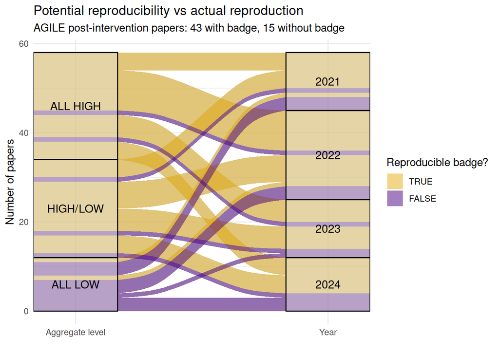

Figure 1

```r
papers_agile_post_sankey <-
  papers_agile_post |>
  dplyr::group_by(agile_badge, agg_level, year) |>
  dplyr::tally()

ggplot2::ggplot(papers_agile_post_sankey,
                #aes(axis1 = agg_level, axis2 = year, axis3 = agile_badge, y = n)) +
                aes(axis1 = agg_level, axis2 = year, y = n)) +
  #ggplot2::scale_x_discrete(limits = c("Aggregate level", "Year", "Badge"), expand = c(.1, .05)) +
  ggplot2::scale_x_discrete(limits = c("Aggregate level", "Year"), expand = c(.1, .05)) +
  #ggplot2::scale_fill_brewer(type = "qual", palette = "Dark2") +
  # Manual color selection
  ggplot2::scale_fill_manual(values = c("TRUE" = "#E6AD12", "FALSE" = "#4B0082")) +

  geom_flow() +
  # geom_alluvium = flows between nodes
  ggalluvial::geom_alluvium(aes(fill = agile_badge), width = 1/3) +
  # geom_stratum = nodes (boxes)
  ggalluvial::geom_stratum(alpha = .4, width = 1/3, fill = "lightgrey", color = "black") +
  ggplot2::geom_text(stat = "stratum", aes(label = after_stat(stratum)), size = 4) +
  ggplot2::labs(
    title= "Potential reproducibility vs actual reproduction",
    subtitle = stringr::str_glue("AGILE post-intervention papers: {n_papers_agile_post_with_badge} with badge, {n_papers_agile_post_wo_badge} without badge"),
    x = "",
    y = "Number of papers",
    fill = "Reproducible badge?") +
  ggplot2::theme_minimal() +
  ggplot2::theme(plot.tag = element_text(size = 8)) +
  ggplot2::theme(legend.position = "right")
```

```r
#ggplot2::ggsave(file = here::here("figs", "GIScience_all.svg"),
#       width = 10, height = 7, dpi = 300)
ggplot2::ggsave(file = here::here("figs", "AGILE_sankey_year.png"),
       width = 10, height = 6, dpi = 300)
```

### Second version

Used criteria instead of year, and aggregate level is only High (A,O) and LOW (U, D).

```r
udoa_levels <- c("U", "D", "A", "O", NA)

papers_agile_post <-
  readr::read_csv(here::here("data-clean", "all-data.csv"),
                  col_types = readr::cols(
                    conf = readr::col_character(),
                    year = readr::col_integer(),
                    paper = readr::col_character(),
                    title = readr::col_character(),
                    consolidated_cp = readr::col_logical(),
                    consolidated_data = readr::col_factor(levels = udoa_levels),
                    consolidated_methods = readr::col_factor(levels = udoa_levels),
                    consolidated_results = readr::col_factor(levels = udoa_levels),
                    agile_badge = readr::col_logical()
                  ),
                  na = c("NA", "Not applicable")) |>
  dplyr::filter(conf == "agile" & year > 2020 & consolidated_cp == FALSE) |>
  dplyr::mutate(agile_badge = if_else(is.na(agile_badge), FALSE, TRUE)) |>
  tidyr::pivot_longer(
    cols = c("consolidated_data", "consolidated_methods", "consolidated_results"),
    names_to = "criteria",
    values_to = "level"
  ) |>
  dplyr::mutate(agg_level = case_when(
    level %in% c("A", "O") ~"HIGH",
    level %in% c("U", "D") ~"LOW")) |>
  dplyr::select(year, paper, criteria, level, agg_level, agile_badge) |>
  dplyr::arrange(year)

papers_agile_post <-
  papers_agile_post |>
  dplyr::mutate(agile_badge = forcats::fct_infreq(factor(agile_badge))) |>
  dplyr::mutate(agg_level = forcats::fct_infreq(agg_level))

n_papers_agile_post_with_badge <- nrow(filter(papers_agile_post, agile_badge == TRUE))
n_papers_agile_post_wo_badge <- nrow(filter(papers_agile_post, agile_badge == FALSE))
```

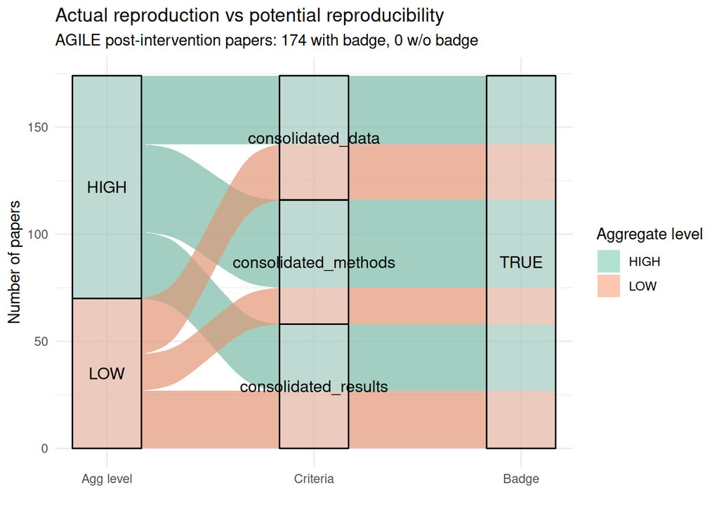

Figure 2

```r
papers_agile_post_sankey <-
  papers_agile_post |>
  dplyr::group_by(agg_level, criteria, agile_badge) |>
  dplyr::tally()

ggplot2::ggplot(papers_agile_post_sankey,
                aes(axis1 = agg_level, axis2 = criteria, axis3 = agile_badge, y = n)) +
  ggplot2::scale_x_discrete(limits = c("Agg level", "Criteria", "Badge"), expand = c(.1, .05)) +
  ggplot2::scale_fill_brewer(type = "qual", palette = "Set2") +
  geom_flow() +
  # geom_alluvium = flows between nodes
  ggalluvial::geom_alluvium(aes(fill = agg_level), width = 1/3) +
  # geom_stratum = nodes (boxes)
  ggalluvial::geom_stratum(alpha = .4, width = 1/3, fill = "lightgrey", color = "black") +
  ggplot2::geom_text(stat = "stratum", aes(label = after_stat(stratum)), size = 4) +
  ggplot2::labs(
    title= "Actual reproduction vs potential reproducibility",
    subtitle = stringr::str_glue("AGILE post-intervention papers: {n_papers_agile_post_with_badge} with badge, {n_papers_agile_post_wo_badge} w/o badge"),
    x = "",
    y = "Number of papers",
    fill = "Aggregate level") +
  ggplot2::theme_minimal() +
  ggplot2::theme(plot.tag = element_text(size = 8)) +
  ggplot2::theme(legend.position = "right")
```

```r
#ggplot2::ggsave(file = here::here("figs", "GIScience_all.svg"),
#       width = 10, height = 7, dpi = 300)
ggplot2::ggsave(file = here::here("figs", "AGILE_sankey_criteria.png"),
       width = 10, height = 6, dpi = 300)
```